# Week 14

# 1 Sentiment

Sentiment analysis attempts to assign scores or moods to text. Recall Figure 13.3 from the textbook.

## 1.1 13.2.3 DIY

*From Chapter 13*

In this DIY, we turn to a Wikipedia entry about the 1979 Oil Crisis that had a substantial effect on the Western World’s economy.[^1]. The article on the Oil Crisis presents both positive and negative effects – a perfect example of how sentiment analysis can summarize a body of text. The first paragraph describes the magnitude of the crisis:

> The 1970s energy crisis occurred when the Western world, particularly the United States, Canada, Western Europe, Australia, and New Zealand, faced substantial petroleum shortages, real and perceived, as well as elevated prices. The two worst crises of this period were the 1973 oil crisis and the 1979 energy crisis, when the Yom Kippur War and the Iranian Revolution triggered interruptions in Middle Eastern oil exports.

Whereas the sixth paragraph softens the implications, turning to instances where the crisis had a far less adverse impact:

> The period was not uniformly negative for all economies. Petroleum-rich countries in the Middle East benefited from increased prices and the slowing production in other areas of the world. Some other countries, such as Norway, Mexico, and Venezuela, benefited as well. In the United States, Texas and Alaska, as well as some other oil-producing areas, experienced major economic booms due to soaring oil prices even as most of the rest of the nation struggled with the stagnant economy. Many of these economic gains, however, came to a halt as prices stabilized and dropped in the 1980s.

Our objective with this DIY is to show how sentiment evolves over the first six paragraphs as scored by the Bing Lexicon implemented in the `tidytext` package. To start, we read the raw text from the `wiki-article.txt` file.

```r
#Read text article
  wiki_article <- readLines("https://raw.githubusercontent.com/DataScienceForPublicPolicy/diys/main/data/wiki-article.txt")
```

To make use of the text, we tokenize the six paragraphs of text, remove stop words, then apply a left join with the Bing lexicon. The resulting table contains both matching and non-matching terms and aggregates term frequencies by paragraph `para`, `word`, and `sentiment`. In total, $n = 18$ words are labeled negative and $n=11$ words are positive.

```r
#Set up in data frame
  wiki_df <- data.frame(para = 1:length(wiki_article),
                        text = wiki_article,
                        stringsAsFactors = FALSE)

#Join tokens to lexicon
  sent_df <- wiki_df %>%
    unnest_tokens(word, text) %>%
    anti_join(get_stopwords(language = "en")) %>%
    left_join(get_sentiments("bing")) %>%
    count(para, word, sentiment, sort = TRUE)

#Label terms without sentiment
  sent_df$sentiment[is.na(sent_df$sentiment)] <- "none"
```

Next, we write a basic function to calculate various sentiment metrics such as polarity and expressiveness. Packages such as `sentimentr` implement scoring, but as rules-based sentiment analysis is fairly simple, we directly implement metrics in the formula to illustrate their accessibility.

```r
  sentMetrics <- function(n, s){

    #Set input metrics
      N <- sum(n, na.rm = T)
      x_p <- sum(n[s =="positive"], na.rm = T)
      x_n <- sum(n[s =="negative"], na.rm = T)

    #Calculate scores
      return(data.frame(count.positive = x_p,
                        count.negative = x_n,
                        net.sentiment = (x_p - x_n) / N,
                        expressiveness = (x_p + x_n) / N,
                        positivity = x_p / N,
                        negativity = x_n / N,
                        polarity = (x_p - x_n) / (x_p + x_n))
      )

  }
```

The function is designed to work on one document at a time, requiring a loop to score each paragraph in the article. We iterate over each paragraph using `lapply`, returning the results in a data frame `rated`.

```r
#Apply sentiment scores to each paragraph
  rated <- lapply(sort(unique(sent_df$para)), function(p){
                    para_df <- sent_df %>% filter(para == p)
                    output <- sentMetrics(n = para_df$n,
                                          s = para_df$sentiment)
                    return(data.frame(para = p,
                                      output))
                  })

#Bind into a data frame
  rated <- do.call(rbind, rated)
```

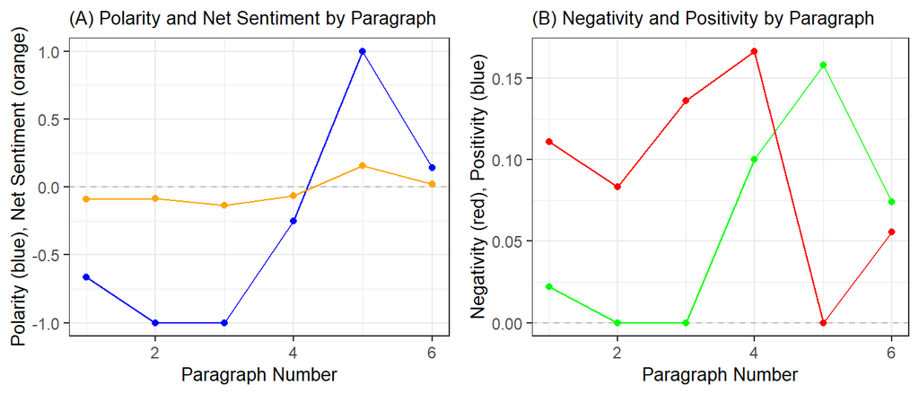

Sentiment scores for the first six paragraphs of the Wikipedia article on 1979 Oil Crisis. Graph (A) illustrates net sentiment and polarity. Graph (B) plots positivity and negativity.

# 2 Regression Example

```r
#devtools::install_github("EmilHvitfeldt/scotus")
library(scotus)

scotus_filtered %>%
  slice_sample(n=5) %>%
  as_tibble()
```

| year | case_name | docket_number | id | text |
| --- | --- | --- | --- | --- |
| 1977 | Idaho Dept. of Employment v. Smith | 76-1291 | 94109 | No. 76-1291.\nPER CURIAM.\nPetitioner challenges a ruling of the Idaho Supreme Court that the denial of unemployment benefits to otherwise eligible persons who attend school during the day violates th… |
| 1896 | Perego v. Dodge | 273 | 78856 | No. 273.\nAction by William Perego against W. H. Dodge, E. P. Ferry, A. B. Richardson, J. N. Jacobson, Martin McGrath, and Mrs. Martin McGrath. From a judgment of the territorial supreme court affirmi… |
| 1919 | Lincoln Gas & Elec. Light Co. v. City of Lincoln | 52 | 83803 | No. 52.\n[Syllabus from pages 256-258 intentionally omitted]\nMessrs. Robert Burns, of New York City, E. C. Strode, of Lincoln, Neb., and Charles A. Frueauff, of New York City, for appellant.\nMessrs.… |
| 1971 | Palmer v. Thompson | 107 | 1296503 | Supreme Court of United States.\n*218 Paul A. Rosen and William M. Kunstler argued the cause for petitioners. With them on the briefs were Ernest Goodman and Arthur Kinoy.\nWilliam F. Goodman, Jr., ar… |
| 1973 | Cinema Classics, Ltd., Inc. v. Joseph P. Busch, Jr., District Attorney, Los Angeles County, State of California | 72-1510 | 93293 | No. 72-1510.\nThe judgment is affirmed.\nMr. Justice BRENNAN, with whom Mr. Justice STEWART and Mr. Justice MARSHALL concur, dissenting.\n'Every person who knowingly sends or causes to be sent, or bri… |

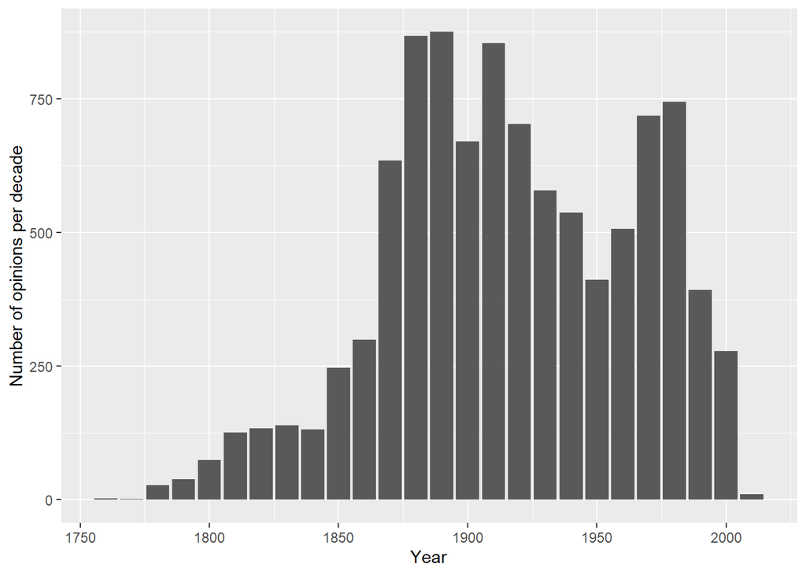

```r
scotus_filtered %>%
  mutate(year = as.numeric(year),
         year = 10 * (year %/% 10)) %>%
  count(year) %>%
  ggplot(aes(year, n)) +
  geom_col() +
  labs(x = "Year", y = "Number of opinions per decade")
```

```r
scotus_split <- scotus_filtered %>%
  mutate(year = as.numeric(year),
         text = str_remove_all(text, "'")) %>%
  slice_sample(n=100) %>%
  initial_split()

scotus_train <- training(scotus_split)
scotus_test <- testing(scotus_split)
```

```r
final_rec <- recipe(year ~ text, data = scotus_train) %>%
  step_tokenize(text) %>%
  step_tokenfilter(text, max_tokens = 1e3) %>%
  step_tfidf(text) %>%
  step_normalize(all_predictors())
```

```r
svm_spec <- svm_linear() %>%
  set_mode("regression") %>%
  set_engine("LiblineaR")

final_workflow <- workflow() %>%
  add_recipe(final_rec) %>%
  add_model(svm_spec)

scotus_folds <- vfold_cv(scotus_train, v = 5)

final_rs <- fit_resamples(
  final_workflow,
  scotus_folds,
  metrics = metric_set(rmse, mae, mape),
  control = control_resamples(save_pred = TRUE, verbose=TRUE)
)
```

[output not shown]

[output not shown]

[output not shown]

[output not shown]

[output not shown]

[output not shown]

[output not shown]

[output not shown]

[output not shown]

[output not shown]

[output not shown]

[output not shown]

[output not shown]

[output not shown]

[output not shown]

[output not shown]

[output not shown]

[output not shown]

[output not shown]

[output not shown]

[output not shown]

[output not shown]

[output not shown]

[output not shown]

[output not shown]

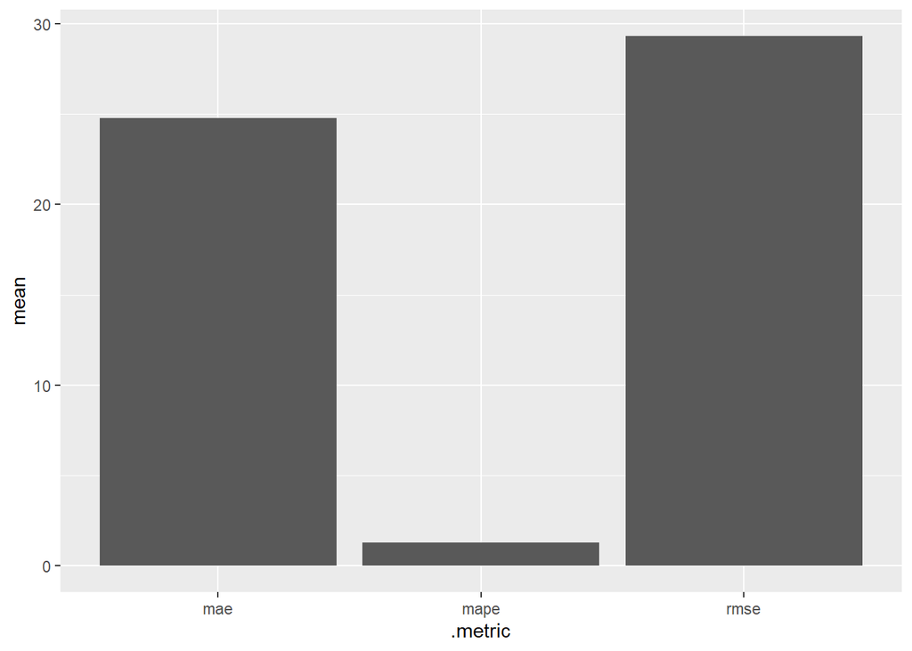

```r
final_rs %>%
  collect_metrics() %>%
  ggplot(aes( x=.metric, y=mean)) +
  geom_bar(stat='identity')
```

```r
final_fitted <- last_fit(final_workflow, scotus_split)

collect_metrics(final_fitted)
```

| .metric | .estimator | .estimate | .config |
| --- | --- | --- | --- |
| rmse | standard | 24.7701091 | Preprocessor1_Model1 |
| rsq | standard | 0.7658376 | Preprocessor1_Model1 |

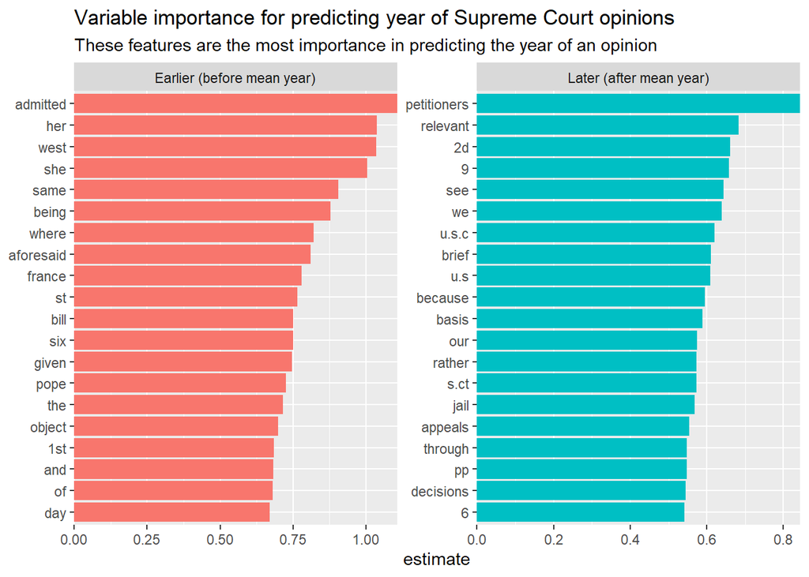

```r
scotus_fit <- extract_fit_parsnip(final_fitted$.workflow[[1]])

scotus_fit %>%
  tidy() %>%
  filter(term != "Bias") %>%
  mutate(
    sign = case_when(estimate > 0 ~ "Later (after mean year)",
                     TRUE ~ "Earlier (before mean year)"),
    estimate = abs(estimate),
    term = str_remove_all(term, "tfidf_text_")
  ) %>%
  group_by(sign) %>%
  top_n(20, estimate) %>%
  ungroup() %>%
  ggplot(aes(x = estimate,
             y = fct_reorder(term, estimate),
             fill = sign)) +
  geom_col(show.legend = FALSE) +
  scale_x_continuous(expand = c(0, 0)) +
  facet_wrap(~sign, scales = "free") +
  labs(
    y = NULL,
    title = paste("Variable importance for predicting year of",
                  "Supreme Court opinions"),
    subtitle = paste("These features are the most importance",
                     "in predicting the year of an opinion")
  )
```

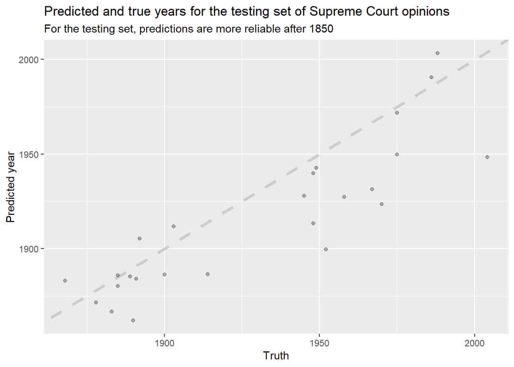

```r
final_fitted %>%
  collect_predictions() %>%
  ggplot(aes(year, .pred)) +
  geom_abline(lty = 2, color = "gray80", size = 1.5) +
  geom_point(alpha = 0.3) +
  labs(
    x = "Truth",
    y = "Predicted year",
    title = paste("Predicted and true years for the testing set of",
                  "Supreme Court opinions"),
    subtitle = "For the testing set, predictions are more reliable after 1850"
  )
```

[^1]: The Wikipedia article on the Oil Crisis can be found at https://en.wikipedia.org/wiki/1979_oil_crisis